# SnowMelt Decoder Dye3 — Encoder Heads Greenland 2026

Vertikales Schmelzprofil (IMEI 301434062008160) — Decode, Diagnostik & Plots

Author

Thom Laepple

Published

September 24, 2026

Der **zweite SnowMelt-Kopf** (IMEI **301434062008160**) an **Dye3**: 24 Knoten mit je NTC1 / NTC2 / NTC3 (TestSB), Abstand 4 cm — baugleich zum NEWGRIP-Kopf. Dieses Dokument decodiert die `.bin`-Nachrichten und zeichnet das Schmelz-/Temperaturprofil. **Montage:** das untere Kettenende hängt seit der Installation **~40 cm über der Schneeoberfläche** — Sensoren schneien erst ein, wenn ~40 cm Netto-Akkumulation aufgelaufen sind (siehe „Einschneidiagnostik”).

Die beiden Schwesterdokumente: **`decode_snowmelt_newgrip.qmd`** für den Kopf am GRIP-Standort (IMEI 300434065508020) und **`decode_chain.qmd`** für die Kette (IMEI 301434062008130). Die gemeinsamen Decode- und Kalibrierfunktionen liegen in `decode_core.R`.

**Bekannter Defekt: `N28_NTC2`** — der mittlere Sensor des untersten Knotens (Position 1). Er läuft in seinem 3-Byte-Feld über, wodurch die Datei 226 statt 225 B misst; der Decoder gibt ihn von selbst als `NA` zurück. Keine Ausschlussliste nötig.

**Bauform der untersten zwei Knoten (Positionen 1–2):** dort steht die Platine mit den NTCs etwas **aus dem Rohr heraus**, abgedichtet mit weißem Silikon — also 6 NTC-Positionen (davon `N28_NTC2` defekt, d. h. 5 funktionierende), die thermisch schwächer ans Rohr gekoppelt sind und mehr Luft- statt Rohrtemperatur sehen. Erwartung: der an den Standardknoten beobachtete NTC2-Mehr-Tagesgang (Rohr-/Kanal-Effekt) sollte hier fehlen oder deutlich kleiner sein — geprüft im Bauform-Check der NTC2-Diagnose.

```r
source("decode_core.R")
```

## Parameters

Edit this block, then re-render (`Ctrl+Shift+K`).

```r
# Identification is purely by IMEI — the "IMEI: <id>" line in the Cloudloop mail,
# which is also the .bin filename prefix (e.g. 301434062008160-35.bin). For a .bin
# attachment the IMEI is auto-detected from the filename; the head's n_nodes /
# fields / type / spacing then come from head_config[[IMEI]].
IMEI <- ""   # "" = auto-detect from BIN_FILE; set manually for a hex payload

# Path(s) to the .bin attachment(s) from the Cloudloop email ------------------
# One file → single decode. A VECTOR of files → a time series: the newest message
# drives the single-message sections (summary, table, profile), and ALL files
# feed the "Zeitlicher Verlauf" plot. All files must be the same head (same IMEI).
BIN_FILE <- Sys.glob("../testdata/301434062008160-*.bin")

# OR paste hex payload(s) from the email (set IMEI above, leave BIN_FILE = "")--
MSG1 <- ""
MSG2 <- ""
```

```r
head_config <- list(
  # SnowMelt head, KEYED BY IMEI. `label` is a human name; n_nodes / fields /
  # type / spacing_cm are authoritative for decoding & plots. `calibration` =
  # path to a per-sensor lab table (position,node,ntc,a,b,c,d); NA → decode with
  # the universal mean lab-S4 curve.
  #
  # Node order (bottom → top) and the coefficients behind the calibration table
  # come from ntc2_investigation/build_calibration_assignment.R; the order is the
  # same as ntc_nodes in ~/sharedAI/thermoheadlogger/param_head.txt. UNLIKE the
  # NEWGRIP head (SM1/SM2 lab tables) this head is calibrated from the
  # Calibration Registry, which covers all 72 channels and includes the
  # 2026-07-06/07 recalibration (TL, 2026-07-15).
  "301434062008160" = list(label = "Snowmelt Dye3", n_nodes = 24L,
                 fields = c("ntc1", "ntc2", "testSB"),
                 type = "snowmelt", spacing_cm = 4L,
                 calibration = "../meta/calibration_assignment_301434062008160.csv")
)

# --- Identify head by IMEI ---------------------------------------------------
bin_files <- BIN_FILE[nzchar(BIN_FILE)]
use_bin   <- length(bin_files) > 0L

imei <- if (IMEI != "") {
  IMEI
} else if (use_bin) {
  imeis <- unique(sub("-.*$", "", basename(bin_files)))
  if (length(imeis) > 1L)
    stop("BIN_FILE mixes IMEIs (", paste(imeis, collapse = ", "),
         ") — a time series must be one head.")
  imeis
} else {
  stop("Set IMEI (hex payload) or BIN_FILE (.bin attachment).")
}
cfg  <- head_config[[imei]]
if (is.null(cfg))
  stop(sprintf("IMEI '%s' is not in head_config (this is the SnowMelt document; the chain lives in decode_chain.qmd).", imei))

n_nodes <- cfg$n_nodes
fields  <- cfg$fields

# --- Per-sensor lab calibration (optional, keyed by head) --------------------
# NTC_s4 per sensor where a lab fit exists (and is numerically sane), else the
# universal mean lab-S4 curve (NTC_mean). See decode_core.R::calibrate_channel.
cal_path <- cfg$calibration
lab_cal  <- load_lab_cal(cal_path, n_nodes)     # nested [field][position] coefs, or NULL

n_lab_sensors <- if (is.null(lab_cal)) 0L else
  sum(sapply(names(lab_cal), function(ch)
    if (ch %in% fields) sum(!vapply(lab_cal[[ch]], is.null, logical(1))) else 0L))
n_ntc_sensors <- n_nodes * sum(fields %in% names(ntc_channel))
cal_method <- if (is.null(lab_cal)) "Mittlere Lab-S4-Kurve (universeller Fallback)" else
  sprintf("Lab-S4 pro Sensor (%d/%d) mit Mean-S4-Fallback", n_lab_sensors, n_ntc_sensors)

# --- File-size sanity check (sep vs nosep variant) ---------------------------
if (!use_bin) {
  n_hex_node   <- sum(ifelse(fields %in% c("ntc1", "ntc2", "testSB", "pressure"), 6L, 4L))
  expected_hex <- 8L + 6L + n_nodes * n_hex_node + 4L
} else {
  exp_len <- bin_expected_len(n_nodes, fields)
  for (bf in bin_files) {
    n_file  <- file.info(bf)$size
    surplus <- n_file - exp_len$sep
    ok <- n_file == exp_len$nosep || (surplus >= 0L && surplus <= n_nodes)
    if (!ok)
      warning(sprintf("%s is %d B but IMEI %s (%s) implies %d B (with) or %d B (without separators) for %d nodes — check head_config",
                      basename(bf), n_file, imei, paste(fields, collapse = "/"),
                      exp_len$sep, exp_len$nosep, n_nodes))
    else if (surplus > 0L)
      message(sprintf("%s is %d B (+%d over %d) — likely a defective sensor sending an oversized value; affected field(s) will read NA.",
                      basename(bf), n_file, surplus, exp_len$sep))
  }
}
```

## Decode

```r
library(dplyr)
library(tidyr)
library(ggplot2)
library(patchwork)

if (use_bin) {
  # ---- Binary snowchain path ------------------------------------------------
  # Decode every file, order oldest → newest. The NEWEST message is the "primary"
  # one shown in the single-message sections; all feed "Zeitlicher Verlauf".
  all_bin <- lapply(bin_files, read_snowchain_bin, fields = fields, n_nodes = n_nodes)
  ord       <- order(sapply(all_bin, `[[`, "time_unix"))
  all_bin   <- all_bin[ord]
  bin_files <- bin_files[ord]
  n_msg     <- length(all_bin)

  bin          <- all_bin[[n_msg]]
  primary_file <- bin_files[n_msg]
  time_utc   <- unix2utc(bin$time_unix)
  adc_temp_C <- adc2temp(bin$adc_temp)
  battery_mv <- bin$battery_mv
  battery_lo <- bin$battery_lo
  battery_hi <- bin$battery_hi
  battery_partial <- bin$battery_partial
  bin_fmt    <- if (bin$has_sep) "0x7C-separated" else "no separators"

  nodes <- bin_to_nodes(bin, fields, lab_cal)

} else {
  # ---- Hex email path -------------------------------------------------------
  hex <- toupper(trimws(paste0(MSG1, MSG2)))

  if (nchar(hex) == 0) {
    cat("No payload — set BIN_FILE or paste hex into MSG1 / MSG2 above and re-render.\n")
    knitr::knit_exit()
  }

  if (nchar(hex) != expected_hex) {
    warning(sprintf(
      "Expected %d hex chars (%d bytes) for IMEI %s, got %d. Payload may be incomplete.",
      expected_hex, expected_hex %/% 2L, imei, nchar(hex)
    ))
  }

  schema <- build_schema(n_nodes, fields)
  raw    <- decode_hex(schema, hex)

  time_utc   <- unix2utc(raw$time_unix)
  adc_temp_C <- adc2temp(raw$adc_temp)
  battery_mv <- as.integer(raw$battery_mv)
  battery_lo <- battery_mv; battery_hi <- battery_mv; battery_partial <- FALSE
}
```

## Diagnostics

```r
check <- function(val, lo, hi, label, unit) {
  ok  <- !is.na(val) && val >= lo && val <= hi
  col <- if (ok) "#2ecc71" else "#e74c3c"
  tag <- if (ok) "OK" else "CHECK"
  cat(sprintf('<span style="color:%s">%s</span>  **%s**: %.1f %s  *(expected %g – %g)*\n\n',
              col, tag, label, val, unit, lo, hi))
}
```

**NoteMessage summary — Snowmelt Dye3 (IMEI 301434062008160)**

| **Time (UTC)** | 2026-09-24 09:24:56 |
| --- | --- |
| **Battery** | 6967 mV |
| **ADC temp** | -22.8 °C |
| **Kalibrierung** | Lab-S4 pro Sensor (72/72) mit Mean-S4-Fallback |
| **Source** | binary: 301434062008160-rb2609240924.bin (no separators) |
| **Messages loaded** | 572 file(s) — newest shown below; see Zeitlicher Verlauf for the series |

```r
check(battery_mv,  5500, 7200, "Battery",  "mV")
```

OK **Battery**: 6967.0 mV *(expected 5500 – 7200)*

```r
check(adc_temp_C, -60,   40,   "ADC temp", "°C")
```

OK **ADC temp**: -22.8 °C *(expected -60 – 40)*

## Node data

```r
if (!use_bin) {
  # Build nodes dataframe from hex-decoded raw list
  ntc_fields <- fields[fields != "gnd"]
  gnd_field  <- if ("gnd" %in% fields) "gnd" else NULL

  nodes <- data.frame(node = seq_len(n_nodes))

  for (f in ntc_fields) {
    col_raw <- paste0("n", nodes$node, ".", f)
    cnts    <- sapply(col_raw, function(nm) raw[[nm]])
    nodes[[paste0(f, "_counts")]] <- cnts          # raw counts (pre-calibration)
    if (f == "pressure") nodes$pressure_hPa  <- pressure2hPa(cnts)
    else                 nodes[[paste0(f, "_C")]] <- calibrate_channel(cnts, f, lab_cal)
  }

  if (!is.null(gnd_field)) {
    col_raw <- paste0("n", nodes$node, ".gnd")
    nodes$gnd <- sapply(col_raw, function(nm) raw[[nm]])
  }
}

# CSV gets the raw counts too; the on-page table stays calibrated for readability.
src_label <- if (use_bin) basename(primary_file) else cfg$label
knitr::kable(nodes |> select(-ends_with("_counts")), digits = 2,
             caption = sprintf("All nodes — %s | %s UTC",
                               src_label, format(time_utc, "%Y-%m-%d %H:%M")))
```

All nodes — 301434062008160-rb2609240924.bin | 2026-09-24 09:24 UTC

| node | ntc1_C | ntc2_C | testSB_C |
| --- | --- | --- | --- |
| 1 | -28.48 | NA | -28.48 |
| 2 | -28.62 | -28.52 | -28.41 |
| 3 | -27.14 | -27.36 | -27.50 |
| 4 | -27.09 | -27.04 | -27.75 |
| 5 | -27.60 | -27.47 | -27.51 |
| 6 | -27.60 | -27.06 | -27.78 |
| 7 | -27.42 | -26.54 | -27.45 |
| 8 | -27.72 | -27.68 | -26.70 |
| 9 | -27.50 | -27.24 | -27.54 |
| 10 | -27.45 | -27.17 | -27.56 |
| 11 | -27.67 | -26.94 | -27.12 |
| 12 | -26.54 | -26.90 | -27.06 |
| 13 | -26.97 | -26.75 | -27.07 |
| 14 | -27.06 | -26.72 | -26.89 |
| 15 | -27.23 | -26.70 | -26.39 |
| 16 | -27.14 | -27.28 | -27.03 |
| 17 | -27.35 | -26.89 | -27.20 |
| 18 | -27.10 | -27.05 | -27.04 |
| 19 | -27.03 | -27.14 | -26.80 |
| 20 | -26.92 | -26.93 | -26.79 |
| 21 | -26.92 | -26.39 | -27.15 |
| 22 | -26.96 | -26.45 | -27.05 |
| 23 | -27.16 | -26.82 | -27.03 |
| 24 | -26.89 | -26.82 | -26.82 |

## Profil

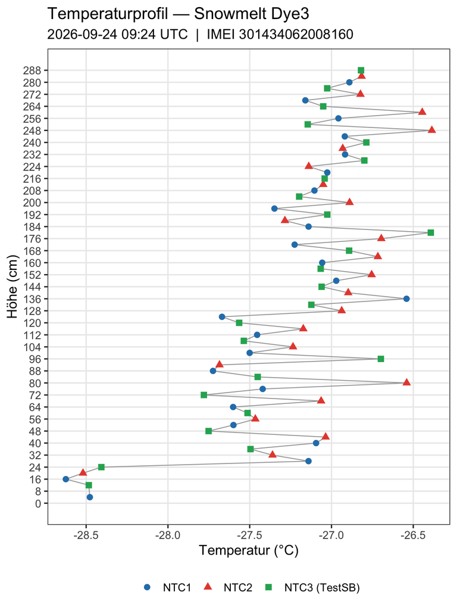

```r
# NTC rank within node: NTC1=1, NTC2=2, TestSB=3; height = (node-1)*3*s + rank*s
s <- cfg$spacing_cm
long <- nodes |>
  select(node, ends_with("_C")) |>
  pivot_longer(ends_with("_C"), names_to = "sensor", values_to = "temp_C") |>
  filter(!is.na(temp_C)) |>          # drop defective sensors (sentinel → NA, e.g. topmost NTC3)
  mutate(
    sensor   = recode(sensor, ntc1_C = "NTC1", ntc2_C = "NTC2", testSB_C = "NTC3 (TestSB)"),
    ntc_rank = case_when(sensor == "NTC1" ~ 1L, sensor == "NTC2" ~ 2L, TRUE ~ 3L),
    hoehe_cm = (node - 1L) * 3L * s + ntc_rank * s
  )

max_h <- n_nodes * 3L * s
ggplot(long, aes(x = temp_C, y = hoehe_cm)) +
  geom_path(data = arrange(long, hoehe_cm), colour = "grey65", linewidth = 0.4) +
  geom_point(aes(colour = sensor, shape = sensor), size = 2.5) +
  scale_y_continuous(
    name   = "Höhe (cm)",
    limits = c(0, max_h),
    breaks = seq(0, max_h, by = max(s, 8L))
  ) +
  scale_x_continuous(name = "Temperatur (°C)") +
  scale_colour_manual(values = c(NTC1 = "#2980b9", NTC2 = "#e74c3c",
                                 "NTC3 (TestSB)" = "#27ae60")) +
  labs(
    title    = sprintf("Temperaturprofil — %s", cfg$label),
    subtitle = sprintf("%s UTC  |  IMEI %s", format(time_utc, "%Y-%m-%d %H:%M"), imei),
    colour   = NULL, shape = NULL
  ) +
  theme_bw(base_size = 13) +
  theme(legend.position = "bottom", panel.grid.minor = element_blank())
```

## Zeitlicher Verlauf

Only shown when more than one `.bin` file is loaded (a time series). Every message contributes; the single-message sections above show the newest one.

```r
multi <- use_bin && exists("all_bin") && n_msg > 1L
```

```r
# Long table across all messages: one row per (time, node, sensor), carrying
# both the calibrated temperature and the raw counts (pre-calibration).
series_wide <- bind_rows(lapply(all_bin, function(b)
  bin_to_nodes(b, fields, lab_cal) |> mutate(time = unix2utc(b$time_unix))))

temp_l <- series_wide |> select(node, time, ends_with("_C")) |>
  pivot_longer(ends_with("_C"), names_to = "sensor", values_to = "temp_C")
cnt_l  <- series_wide |> select(node, time, ends_with("_counts")) |>
  pivot_longer(ends_with("_counts"), names_to = "sensor", values_to = "counts") |>
  mutate(sensor = sub("_counts$", "_C", sensor))

series_long <- left_join(temp_l, cnt_l, by = c("node", "time", "sensor")) |>
  filter(!is.na(temp_C))
```

[figure not shown]

```r
# Two stacked panels over the same time series:
#  (top)    Hovmöller heatmap — Höhe (same axis as the profile plot) × time,
#           fill = temperature. Each measurement is one evenly-spaced column.
#  (bottom) Line plot — temperature vs real time, one line per sensor height,
#           coloured by Höhe; reads the diurnal cooling directly.
s   <- cfg$spacing_cm
ts  <- series_long |>
  mutate(
    sensor    = recode(sensor, ntc1_C = "NTC1", ntc2_C = "NTC2", testSB_C = "NTC3 (TestSB)"),
    ntc_rank  = case_when(sensor == "NTC1" ~ 1L, sensor == "NTC2" ~ 2L, TRUE ~ 3L),
    hoehe_cm  = (node - 1L) * 3L * s + ntc_rank * s,
    height_id = paste(node, sensor)
  )
tlevels <- format(sort(unique(ts$time)), "%m-%d %H:%M")
ts  <- ts |> mutate(tlab = factor(format(time, "%m-%d %H:%M"), levels = tlevels))
max_h <- n_nodes * 3L * s

# Companion strip (left of the heatmap, same y-axis): sensor type at each height.
sensor_cols <- c(NTC1 = "#2980b9", NTC2 = "#e74c3c", "NTC3 (TestSB)" = "#27ae60")
strip_df <- expand.grid(node = seq_len(n_nodes), ntc_rank = 1:3) |>
  mutate(sensor   = factor(c("NTC1", "NTC2", "NTC3 (TestSB)")[ntc_rank],
                           levels = names(sensor_cols)),
         hoehe_cm = (node - 1L) * 3L * s + ntc_rank * s)

p_sensor <- ggplot(strip_df, aes(x = 1, y = hoehe_cm, fill = sensor)) +
  geom_tile() +
  scale_fill_manual(values = sensor_cols, name = NULL) +
  scale_y_continuous(name = "Höhe (cm)", limits = c(0, max_h),
                     breaks = seq(0, max_h, by = max(s, 8L)), expand = c(0, 0)) +
  scale_x_continuous(name = "Sensor", breaks = NULL, expand = c(0, 0)) +
  labs(title = " ", subtitle = " ") +
  theme_bw(base_size = 13) +
  theme(panel.grid = element_blank(), legend.position = "left",
        legend.key.size = unit(0.8, "lines"))

# Two companion curves on the same height axis (variance & mean−trend residual).
sensor_by_h <- strip_df |> select(hoehe_cm, sensor)

var_df <- ts |> group_by(hoehe_cm) |>
  summarise(sd_t = 1.4826 * mad(temp_C, na.rm = TRUE), .groups = "drop") |>
  left_join(sensor_by_h, by = "hoehe_cm") |> arrange(hoehe_cm)

# Mittel−Trend = per-height time-median minus a single LINEAR height trend, once
# with the lab calibration and once with the fixed Beta curve (from counts).
ts <- ts |> mutate(temp_beta = NTC_beta(counts))
lin_offset <- function(col) {
  d <- ts |> select(time, hoehe_cm, y = all_of(col)) |> filter(is.finite(y)) |>
    group_by(time) |> mutate(r = 1000 * (y - fitted(lm(y ~ hoehe_cm)))) |> ungroup()
  d |> group_by(hoehe_cm) |>
    summarise(off_mK = mean(r), se_mK = sd(r) / sqrt(n()), .groups = "drop") |>
    left_join(sensor_by_h, by = "hoehe_cm")
}
off_lab  <- lin_offset("temp_C")
off_beta <- lin_offset("temp_beta")
xr_off   <- range(c(off_lab$off_mK  + 2 * off_lab$se_mK,  off_lab$off_mK  - 2 * off_lab$se_mK,
                    off_beta$off_mK + 2 * off_beta$se_mK, off_beta$off_mK - 2 * off_beta$se_mK),
                  na.rm = TRUE)

ybreaks <- seq(0, max_h, by = max(s, 8L))
p_var <- ggplot(var_df, aes(sd_t, hoehe_cm)) +
  geom_path(colour = "grey75", linewidth = 0.3) +
  geom_point(aes(colour = sensor), size = 1.5) +
  scale_colour_manual(values = sensor_cols, guide = "none") +
  scale_y_continuous(name = NULL, limits = c(0, max_h), breaks = ybreaks, expand = c(0, 0)) +
  scale_x_continuous(name = "SD/Zeit (°C)") +
  labs(title = "Varianz", subtitle = "NTC2 ↑") +
  theme_bw(base_size = 13) +
  theme(axis.text.y = element_blank(), axis.ticks.y = element_blank(),
        panel.grid.minor = element_blank())

# NTC3 calibration outliers (nodes 71/77/80/50/51/26) at their NTC3-row heights.
cal_outlier_h <- c(144, 180, 192, 216, 228, 288)

mk_mean <- function(d, ttl, sub) {
  out <- d |> filter(hoehe_cm %in% cal_outlier_h)
  ggplot(d, aes(off_mK, hoehe_cm)) +
    geom_vline(xintercept = 0, colour = "grey60", linewidth = 0.3) +
    geom_errorbarh(aes(xmin = off_mK - 2 * se_mK, xmax = off_mK + 2 * se_mK),
                   height = 0, colour = "grey70", linewidth = 0.3) +
    geom_path(colour = "grey80", linewidth = 0.3) +
    geom_point(aes(colour = sensor), size = 1.5) +
    geom_point(data = out, shape = 21, size = 3.6, stroke = 0.9,
               colour = "black", fill = NA) +
    scale_colour_manual(values = sensor_cols, guide = "none") +
    scale_y_continuous(name = NULL, limits = c(0, max_h), breaks = ybreaks, expand = c(0, 0)) +
    scale_x_continuous(name = "Mittel−Trend ±2·SE (mK)", limits = xr_off) +
    labs(title = ttl, subtitle = sub) +
    theme_bw(base_size = 13) +
    theme(axis.text.y = element_blank(), axis.ticks.y = element_blank(),
          panel.grid.minor = element_blank())
}
p_mean_lab  <- mk_mean(off_lab,  "Mittel−Trend", "lab-kal. (○ = Kal-Outlier)")
p_mean_beta <- mk_mean(off_beta, "Mittel−Trend", "Beta (fix)")

p_heat <- ggplot(ts, aes(x = tlab, y = hoehe_cm, fill = temp_C)) +
  geom_tile() +
  scale_fill_distiller(palette = "RdYlBu", direction = -1, name = "T (°C)") +
  scale_y_continuous(name = NULL, limits = c(0, max_h),
                     breaks = seq(0, max_h, by = max(s, 8L)), expand = c(0, 0)) +
  labs(title    = sprintf("Zeitlicher Verlauf — %s", cfg$label),
       subtitle = sprintf("%d Messungen  |  IMEI %s", n_msg, imei),
       x = NULL) +
  theme_bw(base_size = 13) +
  theme(axis.text.x = element_text(angle = 45, hjust = 1),
        axis.text.y = element_blank(), axis.ticks.y = element_blank(),
        panel.grid  = element_blank())

p_line <- ggplot(ts, aes(x = time, y = temp_C,
                         group = height_id, colour = hoehe_cm)) +
  geom_line(alpha = 0.5, linewidth = 0.4) +
  geom_point(size = 1) +
  scale_colour_viridis_c(name = "Höhe (cm)") +
  labs(x = "Zeit (UTC)", y = "Temperatur (°C)") +
  theme_bw(base_size = 13)

(p_sensor + p_var + p_mean_lab + p_mean_beta + p_heat +
   plot_layout(widths = c(0.5, 1.3, 1.3, 1.3, 5))) / p_line +
  plot_layout(heights = c(3, 2))
```

## Einschneidiagnostik

Wird das untere Ende der Kette vom Schnee eingegraben? Kriterium ist die **Dämpfung des Tagesgangs**: die Dämpfungstiefe der Tageswelle in trockenem Schnee beträgt ~8–10 cm, ein Sensor unter ≥5 cm Schnee verliert also sichtbar Tagesamplitude, unter ~20 cm bleiben <10 %. Die **Referenz ist die Atmosphäre selbst**: die obersten 25 % der Sensorhöhen messen den ungedämpften Tagesgang am selben Tag mit, im Verhältnis Amplitude/Referenz kürzt sich die Wetterlage heraus. Deshalb genügt **ein einziger voller Messtag** (≥ 4 Messungen über den Tag; Tage mit Referenzamplitude < 2 K — ruhig/bedeckt — werden übersprungen). Der Abschnitt rechnet bei jedem Render neu: (a) Hovmöller des Dämpfungsverhältnisses, (b) das Verhältnisprofil des jüngsten verwertbaren Tages, (c) ein automatisches Urteil (gedämpft = Verhältnis < 0.35).

**Erwartung an diesem Kopf:** das untere Kettenende hängt seit der Installation **~40 cm über der Schneeoberfläche**. Bevor der unterste Sensor einschneit, müssen also erst ~40 cm Netto-Akkumulation auflaufen — dass hier über Wochen nichts passiert, ist erwartungsgemäß.

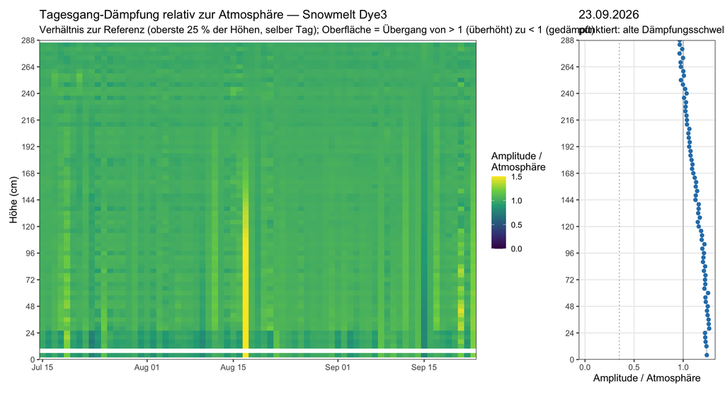

```r
s        <- cfg$spacing_cm
rank_map <- c(ntc1_C = 1L, ntc2_C = 2L, testSB_C = 3L)

amp_d <- series_long |>
  mutate(hoehe_cm = (node - 1L) * 3L * s + rank_map[sensor] * s,
         day      = as.Date(time)) |>
  group_by(hoehe_cm, day) |>
  summarise(amp = diff(range(temp_C)), n_meas = n(), .groups = "drop") |>
  filter(n_meas >= 4L, day > min(day), day < max(day))   # nur volle Tage

# Referenz "Atmosphäre" = Median-Amplitude der obersten 25 % der Höhen AM SELBEN
# Tag; im Verhältnis kürzt sich die Wetterlage heraus → 1 voller Tag genügt.
h_ref <- quantile(unique(amp_d$hoehe_cm), 0.75)
ref_d <- amp_d |> group_by(day) |>
  summarise(ref = median(amp[hoehe_cm >= h_ref]), .groups = "drop")
ratio_d <- amp_d |> left_join(ref_d, by = "day") |>
  filter(ref >= 2) |>            # ruhige/bedeckte Tage (< 2 K oben): kein Urteil möglich
  mutate(ratio = amp / ref)

day_v  <- max(ratio_d$day)       # jüngster verwertbarer Tag
prof_v <- ratio_d |> filter(day == day_v) |> mutate(gedaempft = ratio < 0.35)

# Oberflächenlage aus dem Übergang überhöht -> gedämpft (siehe GRIP-Dokument,
# Abschnitt "Was das Amplitudenprofil wirklich zeigt"): der Sensor unmittelbar
# über der Fläche zeigt einen überhöhten Tagesgang, der erste darunter einen
# gedämpften. Auflösung = Knotenabstand, ohne Dämpfungstiefe und Extrapolation.
h_uebergang <- function(h, r, h_max = h_ref) {
  ue <- h[r > 1.05 & h < h_max]
  if (!length(ue)) return(list(h_gd = NA_real_, h_ue = NA_real_, h_surf = NA_real_,
                               n_gd = NA_integer_))
  h_ue <- min(ue); gd <- h[r < 0.95 & h < h_ue]
  h_gd <- if (length(gd)) max(gd) else NA_real_
  list(h_gd = h_gd, h_ue = h_ue, h_surf = (h_gd + h_ue)/2,
       n_gd = sum(r < 0.95 & h < h_ue))
}
tr_v <- h_uebergang(prof_v$hoehe_cm, prof_v$ratio)

max_h <- n_nodes * 3L * s
p_hov <- ggplot(ratio_d, aes(day, hoehe_cm, fill = pmin(ratio, 1.5))) +
  geom_tile() +
  scale_fill_viridis_c(name = "Amplitude /\nAtmosphäre", limits = c(0, 1.5)) +
  scale_y_continuous("Höhe (cm)", limits = c(0, max_h),
                     breaks = seq(0, max_h, 24), expand = c(0, 0)) +
  scale_x_date(NULL, expand = c(0, 0)) +
  labs(title    = sprintf("Tagesgang-Dämpfung relativ zur Atmosphäre — %s", cfg$label),
       subtitle = "Verhältnis zur Referenz (oberste 25 % der Höhen, selber Tag); Oberfläche = Übergang von > 1 (überhöht) zu < 1 (gedämpft)") +
  theme_bw(base_size = 12) + theme(panel.grid = element_blank())

p_prof <- ggplot(prof_v, aes(ratio, hoehe_cm)) +
  geom_vline(xintercept = 1, colour = "grey70") +
  geom_vline(xintercept = 0.35, linetype = "dotted", colour = "grey60") +
  { if (is.finite(tr_v$h_surf)) geom_hline(yintercept = tr_v$h_surf,
        linetype = "dashed", colour = "firebrick") } +
  geom_path(colour = "grey70", linewidth = 0.4) +
  geom_point(aes(colour = gedaempft), size = 1.8, show.legend = FALSE) +
  scale_colour_manual(values = c(`FALSE` = "#2980b9", `TRUE` = "firebrick")) +
  scale_y_continuous(NULL, limits = c(0, max_h), breaks = seq(0, max_h, 24),
                     expand = c(0, 0)) +
  scale_x_continuous("Amplitude / Atmosphäre", limits = c(0, NA)) +
  labs(title = format(day_v, "%d.%m.%Y"),
       subtitle = if (is.finite(tr_v$h_surf))
         sprintf("rot: Oberfläche %.0f cm (Übergang überhöht → gedämpft)", tr_v$h_surf)
       else "punktiert: alte Dämpfungsschwelle 0.35") +
  theme_bw(base_size = 12) + theme(panel.grid.minor = element_blank())

p_hov + p_prof + plot_layout(widths = c(3.2, 1))
```

```r
bot <- prof_v |> slice_min(hoehe_cm, n = 1)
stand <- format(day_v, "%d.%m.%Y")

if (is.finite(tr_v$h_surf)) {
  cat(sprintf(
    "**Schneeoberfläche bei %.0f ± %.0f cm** auf der Kettenachse (Tages-Check %s). %d cm ist gedämpft (%.0f %% der Atmosphären-Referenz), %d cm überhöht (%.0f %%) — der Sensor unmittelbar über der Fläche sieht deren Tagesgang verstärkt, der erste darunter bereits gedämpft. Gedämpft sind **%d von %d** Sensorhöhen darunter, also **%.0f cm Überdeckung** über dem untersten Sensor (%d cm). Bei ~40 cm Montagehöhe entspricht das ≳ %.0f cm Netto-Akkumulation seit Installation.\n",
    tr_v$h_surf, s/2, stand, tr_v$h_gd, 100*prof_v$ratio[prof_v$hoehe_cm == tr_v$h_gd],
    tr_v$h_ue, 100*prof_v$ratio[prof_v$hoehe_cm == tr_v$h_ue],
    tr_v$n_gd, sum(prof_v$hoehe_cm < tr_v$h_ue),
    tr_v$h_surf - bot$hoehe_cm, bot$hoehe_cm, 40 + tr_v$h_surf - bot$hoehe_cm))
} else if (bot$ratio >= 0.7) {
  cat(sprintf(
    "**Kein Sensor eingeschneit** (Tages-Check %s). Im Profil gibt es keinen Übergang überhöht → gedämpft; der unterste Sensor (%d cm, physisch ~%d cm über der Oberfläche bei Installation) erreicht **%.0f %%** der Atmosphären-Referenz (%.1f von %.1f K). Bei ~40 cm Montagehöhe ist das erwartungsgemäß.\n",
    stand, bot$hoehe_cm, bot$hoehe_cm + 40L, 100*bot$ratio, bot$amp, bot$ref))
} else {
  cat(sprintf(
    "**Grenzfall — kein Übergang im Profil** (Tages-Check %s). Im Profil gibt es keinen Übergang überhöht → gedämpft; der unterste Sensor (%d cm) erreicht **%.0f %%** der Referenz (%.1f von %.1f K). Entweder steht die Oberfläche unterhalb des Kettenendes, oder der Tag ist zu bedeckt für ein Urteil (ohne direkte Einstrahlung fehlt die Überhöhung).\n",
    stand, bot$hoehe_cm, 100*bot$ratio, bot$amp, bot$ref))
}
```

**Kein Sensor eingeschneit** (Tages-Check 23.09.2026). Im Profil gibt es keinen Übergang überhöht → gedämpft; der unterste Sensor (4 cm, physisch ~44 cm über der Oberfläche bei Installation) erreicht **124 %** der Atmosphären-Referenz (16.7 von 13.5 K). Bei ~40 cm Montagehöhe ist das erwartungsgemäß.

```r
if (any(prof_v$gedaempft)) {
  h_snow <- max(prof_v$hoehe_cm[prof_v$gedaempft])
  cat(sprintf(
    "\nZum Vergleich die frühere Schwellenregel: %d von %d Sensorhöhen liegen unter 35 %% der Referenz, die oberste davon bei %d cm. Diese Höhe liegt rund eine Dämpfungstiefe **unter** der Oberfläche und ist deshalb kein Oberflächenmaß.\n",
    sum(prof_v$gedaempft), nrow(prof_v), h_snow))
}

# Frühwarnung: fallendes Verhältnis am untersten Sensor über die letzten
# verwertbaren Tage = einsetzendes Einschneien, bevor die 35 %-Schwelle fällt.
r_bot <- ratio_d |> filter(hoehe_cm == min(hoehe_cm)) |> arrange(day) |> tail(5)
if (!is.finite(tr_v$h_surf) && nrow(r_bot) >= 3 &&
    tail(r_bot$ratio, 1) < 0.7 && tail(r_bot$ratio, 1) < head(r_bot$ratio, 1)) {
  cat(sprintf(
    "\n**Hinweis — beginnende Dämpfung:** das Verhältnis des untersten Sensors fällt über die letzten %d verwertbaren Tage (%s): %s. Das ist das erwartete Muster bei einsetzendem Einschneien; die 35 %%-Schwelle ist noch nicht unterschritten.\n",
    nrow(r_bot), paste(format(range(r_bot$day), "%d.%m."), collapse = " – "),
    paste(sprintf("%.2f", r_bot$ratio), collapse = " → ")))
}
```

### Abgleich mit der nächsten AWS — NASA-SE (NSE)

Die nächste GC-Net/PROMICE-Station zu Dye-3 ist **NASA-SE** (~157 km nordöstlich, 2386 m — ähnliche Höhenlage wie Dye-3 mit ~2480 m; DY2 und South Dome liegen weiter weg). Sie misst die Schneehöhe direkt (SR50) und ist near-real-time frei verfügbar (GEUS-THREDDS, stündlich aktualisiert). Wegen der Entfernung ist das nur ein grober Anhalt für einzelne Schneefall-Events, aber ein guter Anhalt für die Größenordnung der Netto-Akkumulation. Der Block lädt bei jedem Render die Tageswerte neu; ohne Internetverbindung wird der Vergleich übersprungen.

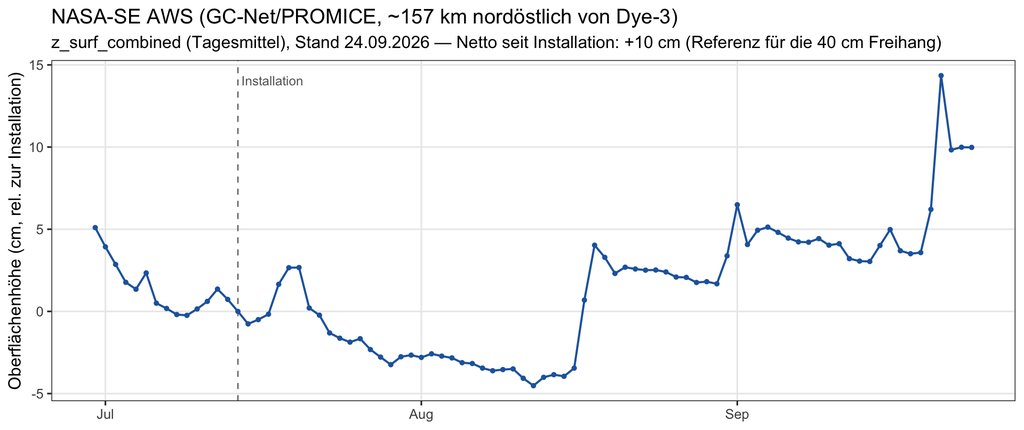

```r
AWS_ID  <- "NSE"
AWS_LBL <- "NASA-SE AWS (GC-Net/PROMICE, ~157 km nordöstlich von Dye-3)"
aws_url <- sprintf("https://thredds.geus.dk/thredds/fileServer/aws/l3sites/csv/day/%s_day.csv", AWS_ID)
aws <- tryCatch({ options(timeout = 60)
  suppressWarnings(readr::read_csv(aws_url, show_col_types = FALSE)) },
  error = function(e) NULL)

if (is.null(aws) || !"z_surf_combined" %in% names(aws)) {
  cat(sprintf("AWS %s nicht erreichbar (%s) — Vergleich übersprungen.\n", AWS_ID, aws_url))
} else {
  t0 <- as.Date(min(series_long$time))
  aw <- aws |> mutate(day = as.Date(time)) |>
    filter(day >= t0 - 14L, is.finite(z_surf_combined)) |>
    group_by(day) |> summarise(z = 100 * mean(z_surf_combined), .groups = "drop")
  z0 <- aw$z[which.min(abs(as.numeric(aw$day - t0)))]
  dz <- tail(aw$z, 1) - z0
  print(
    ggplot(aw, aes(day, z - z0)) +
      geom_vline(xintercept = t0, linetype = "dashed", colour = "grey50") +
      annotate("text", x = t0, y = max(aw$z - z0), label = " Installation",
               hjust = 0, vjust = 1, size = 3.2, colour = "grey40") +
      geom_line(colour = "#2166ac", linewidth = 0.7) +
      geom_point(colour = "#2166ac", size = 1.1) +
      scale_y_continuous("Oberflächenhöhe (cm, rel. zur Installation)") +
      scale_x_date(NULL) +
      labs(title = AWS_LBL,
           subtitle = sprintf("z_surf_combined (Tagesmittel), Stand %s — Netto seit Installation: %+.0f cm (Referenz für die 40 cm Freihang)",
                              format(max(aw$day), "%d.%m.%Y"), dz)) +
      theme_bw(base_size = 12) + theme(panel.grid.minor = element_blank()))
}
```

## NTC2-Diagnose

NTC1 / NTC2 / NTC3 sind je Node quasi am selben Ort, sollten also denselben Tagesgang sehen. Hier wird geprüft, ob **NTC2 systematisch einen stärkeren Tagesgang** hat als die beiden anderen (beobachtet in frühen Felddaten).

```r
safe_amp <- function(x) { x <- x[is.finite(x)]; if (length(x) < 2L) NA_real_ else diff(range(x)) }

diag_long <- series_long |>
  mutate(sensor = recode(sensor, ntc1_C = "NTC1", ntc2_C = "NTC2", testSB_C = "NTC3"))

common_df <- diag_long |> group_by(time) |>
  summarise(common = mean(temp_C, na.rm = TRUE), .groups = "drop")

per_node <- diag_long |>
  left_join(common_df, by = "time") |>
  group_by(node, sensor) |>
  summarise(
    amp   = safe_amp(temp_C),
    slope = if (sum(is.finite(temp_C)) >= 2L)
              cov(temp_C, common, use = "complete.obs") / var(common) else NA_real_,
    .groups = "drop"
  )

amp_w <- per_node |> select(node, sensor, amp) |>
  pivot_wider(names_from = sensor, values_from = amp) |>
  mutate(ref = (NTC1 + NTC3) / 2, d = NTC2 - ref)

summary_tab <- per_node |> group_by(sensor) |>
  summarise(`Amplitude ⌀ (°C)` = mean(amp,   na.rm = TRUE),
            `Slope ⌀`          = mean(slope, na.rm = TRUE),
            `n Nodes`          = sum(!is.na(amp)), .groups = "drop")

n_ok       <- sum(!is.na(amp_w$d))
n_strong   <- sum(amp_w$NTC2 > amp_w$NTC1 & amp_w$NTC2 > amp_w$NTC3, na.rm = TRUE)
amp_diff   <- mean(amp_w$d, na.rm = TRUE)
pval       <- tryCatch(t.test(amp_w$NTC2, amp_w$ref, paired = TRUE)$p.value,
                       error = function(e) NA_real_)
ntc2_amp   <- summary_tab$`Amplitude ⌀ (°C)`[summary_tab$sensor == "NTC2"]
others_amp <- max(summary_tab$`Amplitude ⌀ (°C)`[summary_tab$sensor != "NTC2"])
ntc2_stronger <- isTRUE(ntc2_amp > others_amp) && isTRUE(!is.na(pval) && pval < 0.05)
```

```r
knitr::kable(summary_tab, digits = c(0, 2, 3, 0),
             caption = sprintf("Pro-Sensor-Mittel über %d Messungen", n_msg))
```

Pro-Sensor-Mittel über 572 Messungen

| sensor | Amplitude ⌀ (°C) | Slope ⌀ | n Nodes |
| --- | --- | --- | --- |
| NTC1 | 45.90 | 1.001 | 24 |
| NTC2 | 46.04 | 0.999 | 23 |
| NTC3 | 45.88 | 1.000 | 24 |

```r
col <- if (ntc2_stronger) "#e67e22" else "#2ecc71"
tag <- if (ntc2_stronger) "AUFFÄLLIG" else "unauffällig"
cat(sprintf(
  '<span style="color:%s">**%s**</span> — NTC2 vs. Mittel(NTC1, NTC3), paarweise je Node:\n\n',
  col, tag))
```

**unauffällig** — NTC2 vs. Mittel(NTC1, NTC3), paarweise je Node:

```r
cat(sprintf("- Amplitude im Mittel **%+.2f °C** stärker als NTC1/NTC3.\n", amp_diff))
```

- Amplitude im Mittel **+0.05 °C** stärker als NTC1/NTC3.

```r
cat(sprintf("- NTC2 am stärksten in **%d / %d** Nodes.\n", n_strong, n_ok))
```

- NTC2 am stärksten in **7 / 23** Nodes.

```r
cat(sprintf("- Paired t-Test (Amplitude): **p = %s**.\n",
            if (is.na(pval)) "n/a" else formatC(pval, format = "g", digits = 2)))
```

- Paired t-Test (Amplitude): **p = 0.53**.

```r
cat(sprintf("\n%s\n",
  if (ntc2_stronger)
    "→ NTC2 zeigt einen systematisch stärkeren Tagesgang (wahrscheinlich Kanal-/Sensor-Effekt). Mit mehr vollen Tageszyklen bestätigen."
  else
    "→ Kein systematischer Mehr-Tagesgang von NTC2 in diesen Daten."))
```

→ Kein systematischer Mehr-Tagesgang von NTC2 in diesen Daten.

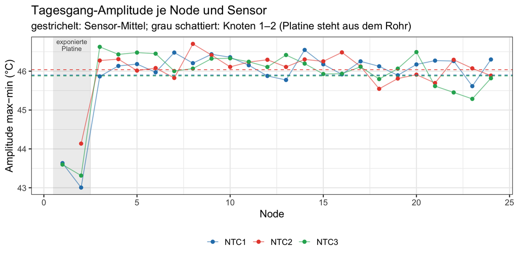

```r
ggplot(per_node, aes(x = node, y = amp, colour = sensor)) +
  annotate("rect", xmin = 0.5, xmax = 2.5, ymin = -Inf, ymax = Inf,
           fill = "grey40", alpha = 0.12) +
  annotate("text", x = 1.5, y = Inf, label = "exponierte\nPlatine", vjust = 1.2,
           size = 2.9, colour = "grey30", lineheight = 0.9) +
  geom_line(alpha = 0.6, linewidth = 0.5) +
  geom_point(size = 1.8) +
  geom_hline(data = summary_tab,
             aes(yintercept = `Amplitude ⌀ (°C)`, colour = sensor),
             linetype = "dashed", linewidth = 0.4, show.legend = FALSE) +
  scale_colour_manual(values = c(NTC1 = "#2980b9", NTC2 = "#e74c3c", NTC3 = "#27ae60")) +
  labs(title = "Tagesgang-Amplitude je Node und Sensor",
       subtitle = "gestrichelt: Sensor-Mittel; grau schattiert: Knoten 1–2 (Platine steht aus dem Rohr)",
       x = "Node", y = "Amplitude max−min (°C)", colour = NULL) +
  theme_bw(base_size = 13) +
  theme(legend.position = "bottom")
```

### Bauform-Check: exponierte Knoten 1–2

An den Knoten 1–2 steht die NTC-Platine aus dem Rohr heraus (weißes Silikon); wenn der NTC2-Mehr-Tagesgang ein **Rohr-/Kanal-Effekt** ist, sollte er dort fehlen. Der Vergleich rechnet auf **Median-Tagesamplituden** je Sensor (nicht auf dem synoptisch dominierten Gesamt-Range): NTC2-Exzess = Tagesamplitude NTC2 − Mittel(NTC1, NTC3), exponierte Knoten gegen die Standardknoten 3–24. Knoten 1 hat kein funktionierendes NTC2 (`N28_NTC2` defekt), dort trägt nur die Gesamtamplituden-Betrachtung bei.

```r
EXPOSED_NODES <- c(1L, 2L)

# Median-Tagesamplitude je (Node, Sensor) — misst den Tagesgang direkt.
day_amp <- series_long |>
  mutate(sensor = recode(sensor, ntc1_C = "NTC1", ntc2_C = "NTC2", testSB_C = "NTC3"),
         day = as.Date(time)) |>
  group_by(node, sensor, day) |>
  summarise(amp = diff(range(temp_C)), n = n(), .groups = "drop") |>
  filter(n >= 4L) |>
  group_by(node, sensor) |>
  summarise(amp = median(amp), .groups = "drop")

aw_day <- day_amp |> pivot_wider(names_from = sensor, values_from = amp) |>
  mutate(d = NTC2 - (NTC1 + NTC3) / 2)
d_exp <- aw_day |> filter(node %in% EXPOSED_NODES, !is.na(d))
d_std <- aw_day |> filter(!node %in% EXPOSED_NODES, !is.na(d))

amp_grp <- day_amp |>
  mutate(grp = ifelse(node %in% EXPOSED_NODES, "exponiert (1–2)", "Standard (3–24)")) |>
  group_by(grp) |> summarise(amp = mean(amp, na.rm = TRUE), .groups = "drop")

cat(sprintf(
  "- NTC2-Exzess an den **exponierten Knoten**: %s (n = %d verwertbar, Knoten %s).\n",
  if (nrow(d_exp)) sprintf("**%+.2f °C**", mean(d_exp$d)) else "—",
  nrow(d_exp), paste(d_exp$node, collapse = ", ")))
```

- NTC2-Exzess an den **exponierten Knoten**: **+0.58 °C** (n = 1 verwertbar, Knoten 2).

```r
cat(sprintf("- NTC2-Exzess an den **Standardknoten 3–24**: **%+.2f °C** (n = %d).\n",
            mean(d_std$d), nrow(d_std)))
```

- NTC2-Exzess an den **Standardknoten 3–24**: **-0.16 °C** (n = 22).

```r
cat(sprintf("- Median-Tagesamplitude (alle NTC): exponiert **%.1f °C** vs. Standard **%.1f °C**.\n",
            amp_grp$amp[amp_grp$grp == "exponiert (1–2)"],
            amp_grp$amp[amp_grp$grp == "Standard (3–24)"]))
```

- Median-Tagesamplitude (alle NTC): exponiert **12.5 °C** vs. Standard **12.8 °C**.

```r
if (nrow(d_exp)) {
  verdict <- if (abs(mean(d_std$d)) < 0.1)
    "→ An den Standardknoten dieses Kopfes gibt es **keinen NTC2-Mehr-Tagesgang** (Exzess ≈ 0) — die Frage, ob die Bauform den Rohr-Effekt beseitigt, stellt sich hier nicht. Auffällig ist stattdessen der **positive Exzess am exponierten Knoten 2** selbst."
  else if (mean(d_exp$d) < 0.5 * mean(d_std$d))
    "→ Der NTC2-Exzess ist an den exponierten Knoten **deutlich kleiner** — konsistent mit einem Rohr-/Kanal-Effekt, den die herausstehende Platine nicht mehr sieht."
  else
    "→ Der NTC2-Exzess ist an den exponierten Knoten **nicht kleiner** — die Bauform allein erklärt den Effekt damit nicht."
  cat("\n", verdict, " (Basis: nur Knoten 2 — schwache Statistik, mit mehr Tageszyklen neu bewerten.)\n", sep = "")
}
```

→ Der NTC2-Exzess ist an den exponierten Knoten **nicht kleiner** — die Bauform allein erklärt den Effekt damit nicht. (Basis: nur Knoten 2 — schwache Statistik, mit mehr Tageszyklen neu bewerten.)

## Strahlungsfehler / Warm-Bias

Unbelüftete Thermistoren in der Sonne lesen über hellem Schnee **zu warm** — die absorbierte Kurzwelle heizt den Fühler über die wahre Lufttemperatur. Der Fehler ist **rein tagseitig** (nachts/bei Tiefsonne null) und lässt sich hier nur **teilweise** aus den Daten festmachen:

- **Fest gemessen — der differentielle Anteil.** Die drei NTC eines Nodes sitzen quasi am selben Ort, müssen also dasselbe lesen. Ihr Spread ist nachts ≈ 0 und wächst bei Sonne — das ist reiner Strahlungsfehler (unterschiedlich beschienene Röhrchen) und eine **Untergrenze** des wahren Bias.
- **Nur eingegrenzt — der gleichsinnige Anteil.** Heizt alle drei Röhrchen gemeinsam, taucht im Spread also *nicht* auf. Er ist der größere Teil (siehe der physikalisch unmögliche Tag-Nacht-Hub unten), lässt sich ohne Wind bzw. einen belüfteten Referenzfühler aber **nicht pro Zeitstempel abziehen**.

**Faustregel für „wie warm war es wirklich”:** Nacht und Tiefsonne (elev ≲ 5°) den Messwerten trauen (Bias ≈ 0); **Tagesspitzen sind Obergrenzen, keine Lufttemperatur.** Es wird hier bewusst **nichts korrigiert** — nur diagnostiziert.

```r
# Sonnenhöhe an DYE3 (~65.18 N, 43.82 W) — dort geht die Sonne unter (echte Nacht
# als strahlungsfreie Referenz), anders als am Polartag-GRIP.
solar_elev <- function(t, lat = 65.18, lon = -43.82) {
  doy  <- as.numeric(format(t, "%j", tz = "UTC"))
  hh   <- as.numeric(format(t, "%H", tz = "UTC")) + as.numeric(format(t, "%M", tz = "UTC")) / 60
  decl <- 23.45 * sin(2 * pi * (284 + doy) / 365) * pi / 180
  H    <- ((hh + lon / 15) - 12) * 15 * pi / 180; latr <- lat * pi / 180
  asin(sin(latr) * sin(decl) + cos(latr) * cos(decl) * cos(H)) * 180 / pi
}

# Differentieller Fehler: Spread der 3 NTC je Node & Zeit, Median über Nodes.
rb <- series_long |> mutate(elev = solar_elev(time))
spread_t <- rb |> group_by(time, node) |>
  summarise(spread = safe_amp(temp_C), .groups = "drop") |>
  group_by(time) |> summarise(spread = median(spread, na.rm = TRUE), .groups = "drop") |>
  left_join(distinct(rb, time, elev), by = "time")

sp_night <- median(spread_t$spread[spread_t$elev < 5],  na.rm = TRUE)
sp_day   <- median(spread_t$spread[spread_t$elev > 25], na.rm = TRUE)

# Gleichsinniger Anteil (indirekt): Tag-Nacht-Hub des Profilmedians.
prof_t <- rb |> group_by(time) |>
  summarise(Tmed = median(temp_C, na.rm = TRUE),
            elev = first(elev), .groups = "drop")
t_night <- min(prof_t$Tmed, na.rm = TRUE)
t_daypk <- max(prof_t$Tmed, na.rm = TRUE)
swing   <- t_daypk - t_night
```

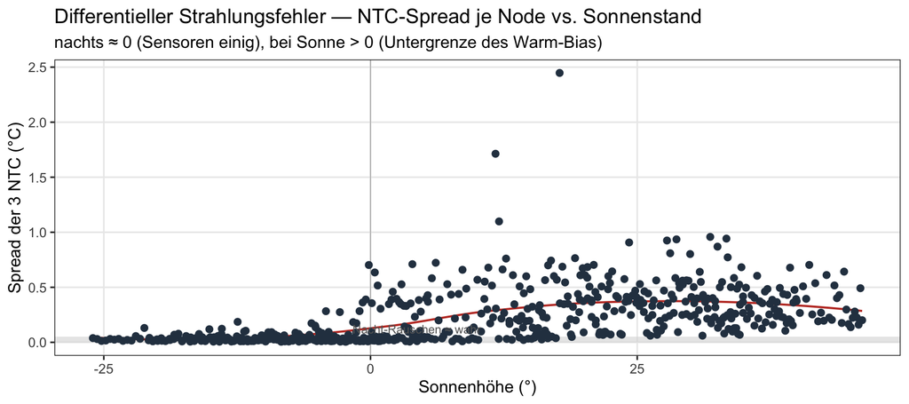

```r
# EIN Zusammenhang (Spread vs. Sonne) → keine Legende; Nacht-Rauschband als Referenz.
ggplot(spread_t, aes(elev, spread)) +
  annotate("rect", xmin = -Inf, xmax = Inf, ymin = 0, ymax = max(sp_night, 0.05),
           fill = "grey85", alpha = 0.6) +
  geom_vline(xintercept = 0, colour = "grey70", linewidth = 0.3) +
  geom_smooth(method = "loess", se = FALSE, colour = "#c0392b", linewidth = 0.7) +
  geom_point(size = 2, colour = "#2c3e50") +
  annotate("text", x = -2, y = max(sp_night, 0.05), label = " Nacht-Rauschen ≈ wahr",
           hjust = 0, vjust = -0.4, size = 3, colour = "grey40") +
  labs(title = "Differentieller Strahlungsfehler — NTC-Spread je Node vs. Sonnenstand",
       subtitle = "nachts ≈ 0 (Sensoren einig), bei Sonne > 0 (Untergrenze des Warm-Bias)",
       x = "Sonnenhöhe (°)", y = "Spread der 3 NTC (°C)") +
  theme_bw(base_size = 12) + theme(panel.grid.minor = element_blank())
```

```r
cat(sprintf("**Differentieller Fehler (fest gemessen):** NTC-Spread nachts **%.2f °C**, bei hoher Sonne (>25°) **%.2f °C** — Faktor ~%.0f. Das ist die *Untergrenze* des Warm-Bias.\n\n",
            sp_night, sp_day, ifelse(sp_night > 0, sp_day / sp_night, NA)))
```

**Differentieller Fehler (fest gemessen):** NTC-Spread nachts **0.03 °C**, bei hoher Sonne (>25°) **0.33 °C** — Faktor ~10. Das ist die *Untergrenze* des Warm-Bias.

```r
cat(sprintf("**Gleichsinniger Fehler (eingegrenzt):** Tag-Nacht-Hub des Profilmedians **%.1f °C** (%.1f → %+.1f °C). Ein solcher Hub ist über schmelznahem Schnee keine reale Lufttemperatur — der Großteil der Nachmittagsspitze ist Strahlungsaufheizung. Größenordnung zur Sonnenspitze **grob +4…+6 °C**, bei Tiefsonne/Nacht ≲ 0,1 °C.\n\n",
            swing, t_night, t_daypk))
```

[output not shown]

```r
cat("**Praktisch:** Nacht-/Tiefsonnenwerte (elev ≲ 5°) sind ~unverzerrt; die Tagesspitzen um mehrere °C zu warm. Eine echte, zeitpunktgenaue Korrektur braucht Wind oder einen belüfteten/beschatteten Referenzfühler — hier bewusst nicht hartkodiert.\n")
```

**Praktisch:** Nacht-/Tiefsonnenwerte (elev ≲ 5°) sind ~unverzerrt; die Tagesspitzen um mehrere °C zu warm. Eine echte, zeitpunktgenaue Korrektur braucht Wind oder einen belüfteten/beschatteten Referenzfühler — hier bewusst nicht hartkodiert.

## Save result

```r
# Newest message → per-node table.
slug    <- if (use_bin) tools::file_path_sans_ext(basename(primary_file)) else paste0("imei", imei)
outfile <- sprintf("data/decoded_%s_%s.csv", slug, format(time_utc, "%Y%m%d_%H%M%S"))
write.csv(nodes, outfile, row.names = FALSE)
cat("Saved:", outfile, "\n")
```

```
Saved: data/decoded_301434062008160-rb2609240924_20260924_092456.csv
```

```r
# Whole time series → one long CSV (time, node, sensor, temp_C).
if (exists("multi") && multi) {
  ts_file <- sprintf("data/series_imei%s_%s.csv", imei, format(time_utc, "%Y%m%d_%H%M%S"))
  write.csv(series_long, ts_file, row.names = FALSE)
  cat("Saved series:", ts_file, "\n")
}
```

```
Saved series: data/series_imei301434062008160_20260924_092456.csv
```